# Landslides

Mahlon Scott

2025-05-17

## Oregon Landslide Dataset

We’ll use a sample dataset taken from the state of oregon, this dataset consists of the locations of historical landslides occuring starting at 1928 and continuing up to 2023, though the data is much denser in recent years as data collection has increased. The raw dataset can be found here: https://arcg.is/OCST5.

### Simple Plots

The most obvious useful covariate for landslide prediction is the variability in elevation in an area, as areas that have large cliffs are naturally more likely to have landslides occur, this relationship can be seen in the plots below.

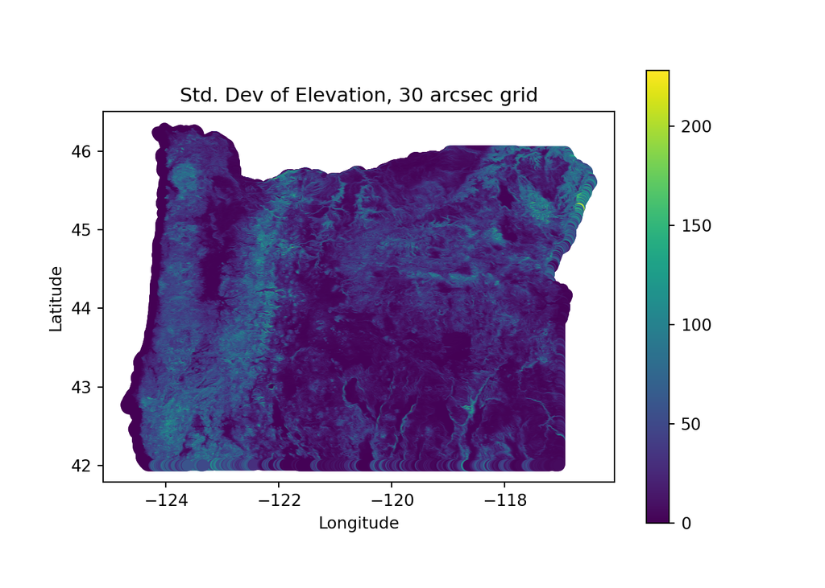

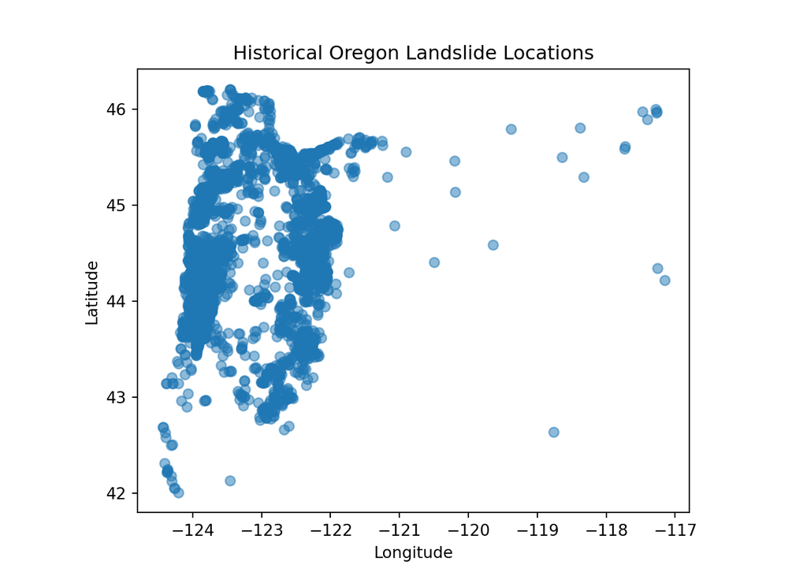

Grouping the data by county, we can apply a zero-inflated negative binomial model to model the landslide frequency in each county. We then have an an s by t matrix, where s is the number of counties, t is the number of years in the dataset, and each entry is a nonnegative integer. The spatiotemporal random effects in the ZINB_NNGP model will account for some of the additional spatial variability not explained just by the standard deviation of the elevation in a region, as well as some of the recording frequency variability.

### Preprocessing the Dataset

```r
observations <- read.table("landslides_county_year.dat")
observations
```

```
##    V1 V2 V3 V4 V5 V6 V7 V8 V9 V10 V11 V12 V13 V14 V15 V16 V17 V18 V19 V20 V21
## 1   0  0  0  0  0  0  0  0  0   0   0   0   0   0   0   0   0   0   0   0   0
## 2   0  0  0  0  0  0  0  0  0   0   0   0   0   0   0   0   0   0   0   0   0
## 3   0  0  0  0  0  0  0  0  0   0   0   0   0   0   0   0   0   0   0   0   0
## 4   0  0  0  0  0  0  0  0  0   0   0   0   0   0   0   0   0   0   0   0   0
## 5   0  0  0  0  0  0  0  0  0   0   0   0   0   0   0   0   0   0   0   0   0
## 6   0  0  0  0  0  0  0  0  0   0   0   0   0   0   0   0   0   0   0   0   0
## 7   0  0  0  0  0  0  0  0  0   0   0   0   0   0   0   1   0   0   0   0   0
## 8   0  0  0  0  0  0  0  0  0   0   0   0   0   0   0   0   0   0   0   0   0
## 9   0  0  0  0  0  0  0  0  0   0   0   0   0   0   7   0   0   0   0   1  14
## 10  0  0  0  0  0  0  0  0  0   0   0   0   0   0   0   0   0   0   0   0   0
## 11  0  0  0  0  0  0  0  0  0   0   0   0   0   0   0   0   0   0   0   0   0
## 12  0  0  0  0  0  0  0  0  0   0   0   0   0   0   0   0   0   0   0   0   0
## 13  0  0  0  0  0  0  0  0  0   0   0   0   0   0   0   0   0   0   0   0   0
## 14  0  0  0  0  0  0  0  0  0   0   0   0   0   0   1   0   0   0   0   0   7
```

[output cut: 133 more lines]

From this observation matrix, we can generate our response vector y, and the spatial and temporal design matrices Vs and Vt.

```r
# Call the helper function for creating the design matrices from the observation
# matrix
out <- make_y_Vs_Vt(observations)
Vs <- out$Vs
Vt <- out$Vt
y <- out$y

# Show quick example of contents of temporal design matrix, the first 6
# observations should correspond to the first time in this dataset.
head(Vt)
```

```
##      [,1] [,2] [,3] [,4] [,5] [,6] [,7] [,8] [,9] [,10] [,11] [,12] [,13] [,14]
## [1,]    0    0    0    0    0    0    0    0    0     0     0     0     0     0
## [2,]    0    0    0    0    0    0    0    0    0     0     0     0     0     0
## [3,]    0    0    0    0    0    0    0    0    0     0     0     0     0     0
## [4,]    0    0    0    0    0    0    0    0    0     0     0     0     0     0
## [5,]    0    0    0    0    0    0    0    0    0     0     0     0     0     0
## [6,]    0    0    0    0    0    0    0    0    0     0     0     0     0     0
##      [,15] [,16] [,17] [,18] [,19] [,20] [,21] [,22] [,23] [,24] [,25] [,26]
## [1,]     0     0     0     0     0     0     0     0     0     0     0     0
## [2,]     0     0     0     0     0     0     0     0     0     0     0     0
## [3,]     0     0     0     0     0     0     0     0     0     0     0     0
## [4,]     0     0     0     0     0     0     0     0     0     0     0     0
## [5,]     0     0     0     0     0     0     0     0     0     0     0     0
## [6,]     0     0     0     0     0     0     0     0     0     0     0     0
##      [,27] [,28] [,29] [,30] [,31] [,32] [,33] [,34] [,35] [,36] [,37] [,38]
```

[output cut: 27 more lines]

```r
# Temporal design matrix
Dt <- as.matrix(unname(read.table("time_dist.dat")))
head(Dt)
```

```
##      [,1] [,2] [,3] [,4] [,5] [,6] [,7] [,8] [,9] [,10] [,11] [,12] [,13] [,14]
## [1,]    0    4    5    9   22   26   28   32   36    37    40    41    42    44
## [2,]    4    0    1    5   18   22   24   28   32    33    36    37    38    40
## [3,]    5    1    0    4   17   21   23   27   31    32    35    36    37    39
## [4,]    9    5    4    0   13   17   19   23   27    28    31    32    33    35
## [5,]   22   18   17   13    0    4    6   10   14    15    18    19    20    22
## [6,]   26   22   21   17    4    0    2    6   10    11    14    15    16    18
##      [,15] [,16] [,17] [,18] [,19] [,20] [,21] [,22] [,23] [,24] [,25] [,26]
## [1,]    45    46    47    49    50    51    52    53    54    55    56    57
## [2,]    41    42    43    45    46    47    48    49    50    51    52    53
## [3,]    40    41    42    44    45    46    47    48    49    50    51    52
## [4,]    36    37    38    40    41    42    43    44    45    46    47    48
## [5,]    23    24    25    27    28    29    30    31    32    33    34    35
## [6,]    19    20    21    23    24    25    26    27    28    29    30    31
##      [,27] [,28] [,29] [,30] [,31] [,32] [,33] [,34] [,35] [,36] [,37] [,38]
```

[output cut: 27 more lines]

```r
scale_t <- 0.0001 * max(Dt) # Set a reasonable scale for the time matrix
Dt <- Dt / scale_t
head(Dt)
```

```
##           [,1]      [,2]      [,3]      [,4]      [,5]      [,6]      [,7]
## [1,]    0.0000  421.0526  526.3158  947.3684 2315.7895 2736.8421 2947.3684
## [2,]  421.0526    0.0000  105.2632  526.3158 1894.7368 2315.7895 2526.3158
## [3,]  526.3158  105.2632    0.0000  421.0526 1789.4737 2210.5263 2421.0526
## [4,]  947.3684  526.3158  421.0526    0.0000 1368.4211 1789.4737 2000.0000
## [5,] 2315.7895 1894.7368 1789.4737 1368.4211    0.0000  421.0526  631.5789
## [6,] 2736.8421 2315.7895 2210.5263 1789.4737  421.0526    0.0000  210.5263
##           [,8]     [,9]    [,10]    [,11]    [,12]    [,13]    [,14]    [,15]
## [1,] 3368.4211 3789.474 3894.737 4210.526 4315.789 4421.053 4631.579 4736.842
## [2,] 2947.3684 3368.421 3473.684 3789.474 3894.737 4000.000 4210.526 4315.789
## [3,] 2842.1053 3263.158 3368.421 3684.211 3789.474 3894.737 4105.263 4210.526
## [4,] 2421.0526 2842.105 2947.368 3263.158 3368.421 3473.684 3684.211 3789.474
## [5,] 1052.6316 1473.684 1578.947 1894.737 2000.000 2105.263 2315.789 2421.053
## [6,]  631.5789 1052.632 1157.895 1473.684 1578.947 1684.211 1894.737 2000.000
##         [,16]    [,17]    [,18]    [,19]    [,20]    [,21]    [,22]    [,23]
```

[output cut: 48 more lines]

```r
# Spatial design matrix, set a reasonable scale here as well
Ds <- as.matrix(unname(read.table("county_dist_scale.dat"))) * 100
```

Then, we need our covariates i.e. the std. dev of elevation (we average this over the entire county in this case to provide a true county-level summary), though the model can accept observation-specific predictors as well.

Since we conveniently have provided the spatial/temporal design matrices, one can just multiply any spatial covariates by the spatial design, and temporal covariates by the temporal design to get the required format for the covariates X.

```r
# Provide elev data on a county-by-county basis
countyData <- read.csv("counties.csv")
X <- Vs %*% countyData$county_elev_std[2:length(countyData$county_elev_std)] # Note this does ignore the covariate at the intercept

# Add an intercept term to X
X <- cbind(1, X)
```

Finally, with our data preprocessed, we just need the spatial coordinates for the spatial NNGP approximation, and we can run the model. These must also be scaled for use in Gaussian kernels, for analyses over larger areas, ensure to scale in a way that minimally distorts distances between point.

```r
countyCoords <- as.matrix(unname(read.table("counties_coords.dat")))
head(countyCoords)
```

```
##            [,1]       [,2]
## [1,] 0.10888247 0.00000000
## [2,] 0.00000000 0.02706125
## [3,] 0.24699913 0.01049753
## [4,] 0.02725383 0.18768201
## [5,] 0.42756421 0.06347546
## [6,] 0.63734239 0.08626451
```

### Results

Now, let’s run the model. This is how you would do it for our dataset.

```r
# Set a prior for the temporal length scale, this ensures that it will be accepted somewhat frequently
# Note that this sampler needs to be run for much longer, more like 300000 iterations to get reasonable convergence
# on this dataset, this is just for demonstration.
ltprior <- list(max = 16, mh_sd = 0.5, a = 1, b = 0.001)
output <- ZINB_GP(X, y, countyCoords, Vs, Vt, Ds, Dt, nsim=20000, burn=2000, print_progress = TRUE, thin=12, save_ypred = TRUE)
```

We’ve cached the output of a much longer run in a file, let’s load that instead of actually running the model.

```r
# Loads the output variable from the model.
load("outMat.rda")
```

Now, we can show some example analyses. Plot typical values of model coefficients.

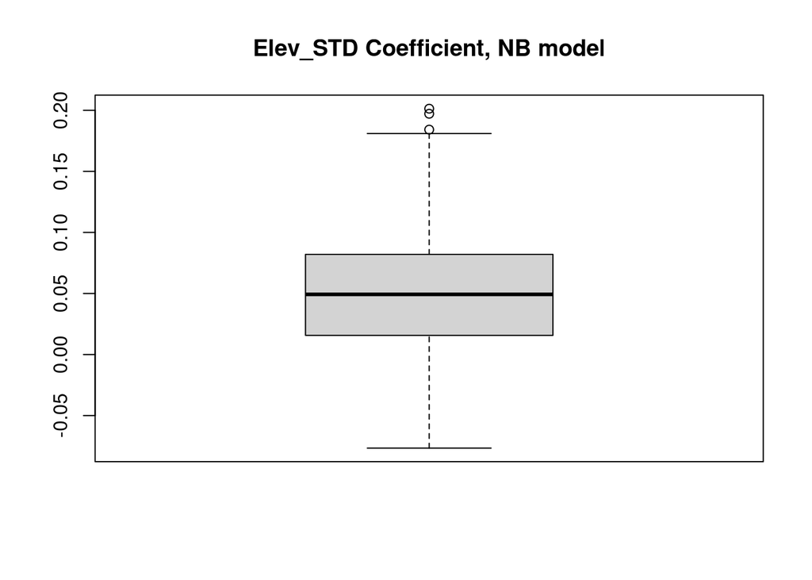

```r
Beta <- output$Beta
boxplot(Beta[,2], main="Elev_STD Coefficient, NB model")
```

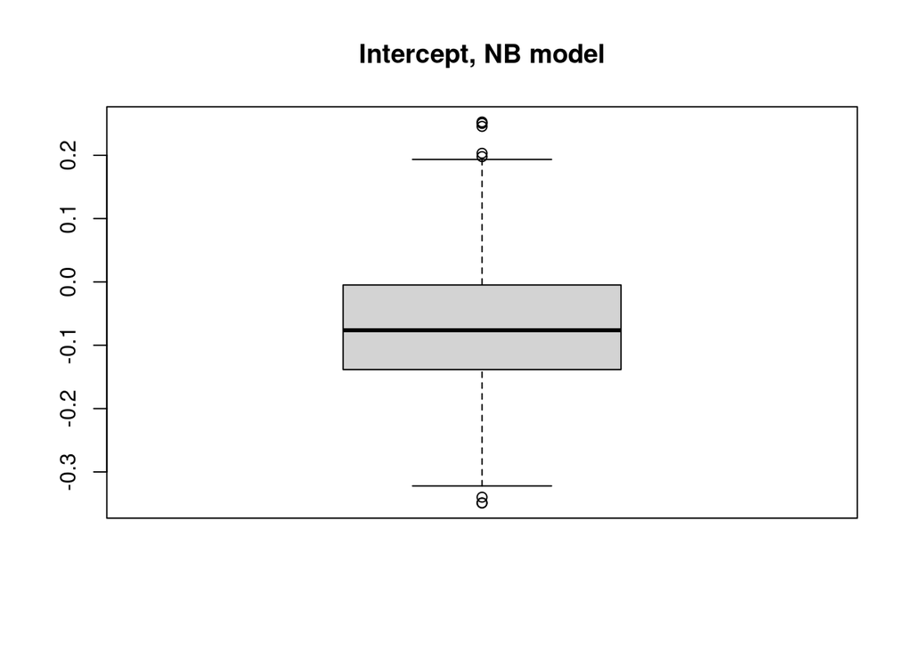

```r
boxplot(Beta[,1], main="Intercept, NB model")
```

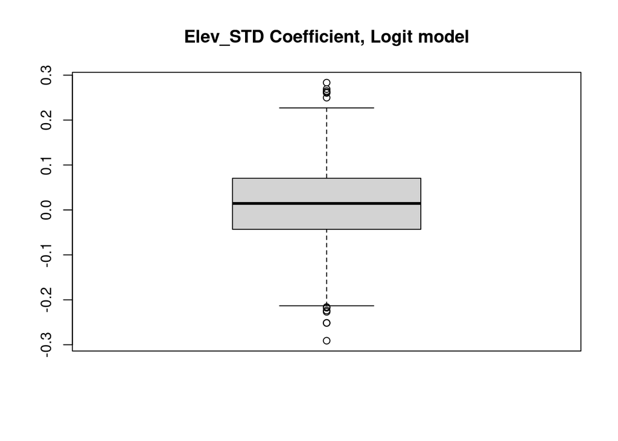

```r
Alpha <- output$Alpha
boxplot(Alpha[,2], main="Elev_STD Coefficient, Logit model")
```

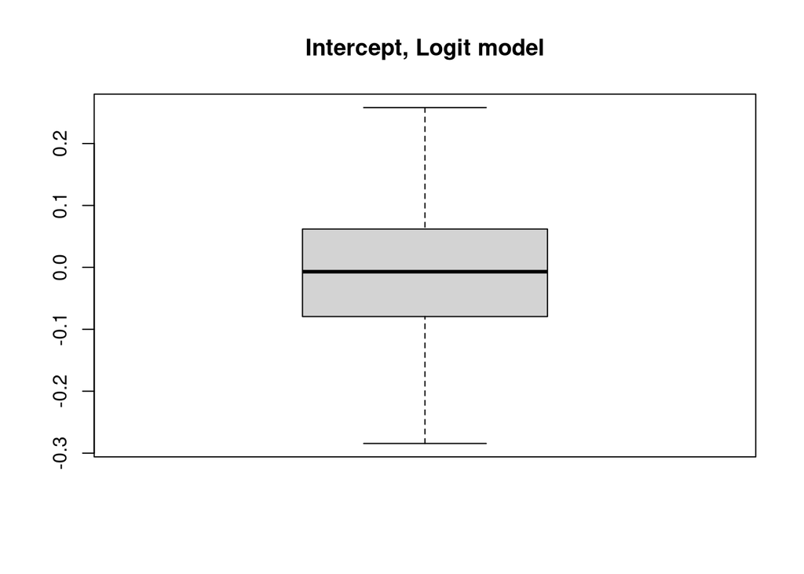

```r
boxplot(Alpha[,1], main="Intercept, Logit model")
```

95% CIs for model coefficients, no coefficients are significant in the NB model, the spatial/temporal effects seem to dominate.

```r
cat("Intercept CI (NB): \n")
```

```
## Intercept CI (NB):
```

```r
quantile(Beta[,1], c(0.025, 0.975))
```

```
##       2.5%      97.5%
## -0.2632794  0.1294125
```

```r
cat("\nElev_STD CI (NB): \n")
```

```
##
## Elev_STD CI (NB):
```

```r
quantile(Beta[,2], c(0.025, 0.975))
```

```
##        2.5%       97.5%
## -0.03550202  0.13384243
```

Now, let’s look at the random effects.

```r
counties <- st_read("./orCounties.geojson")
```

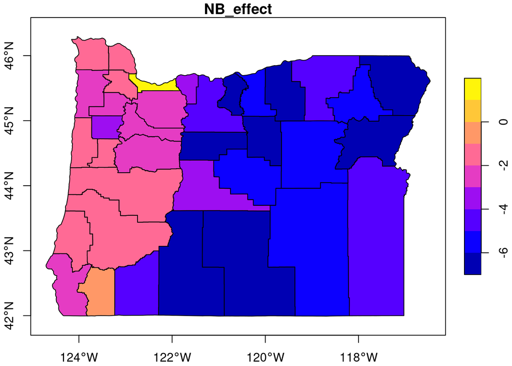

```r
counties$NB_effect <- c(mean(output$Beta[,1]),colMeans(output$C))
plot(counties["NB_effect"], axes=TRUE)
```

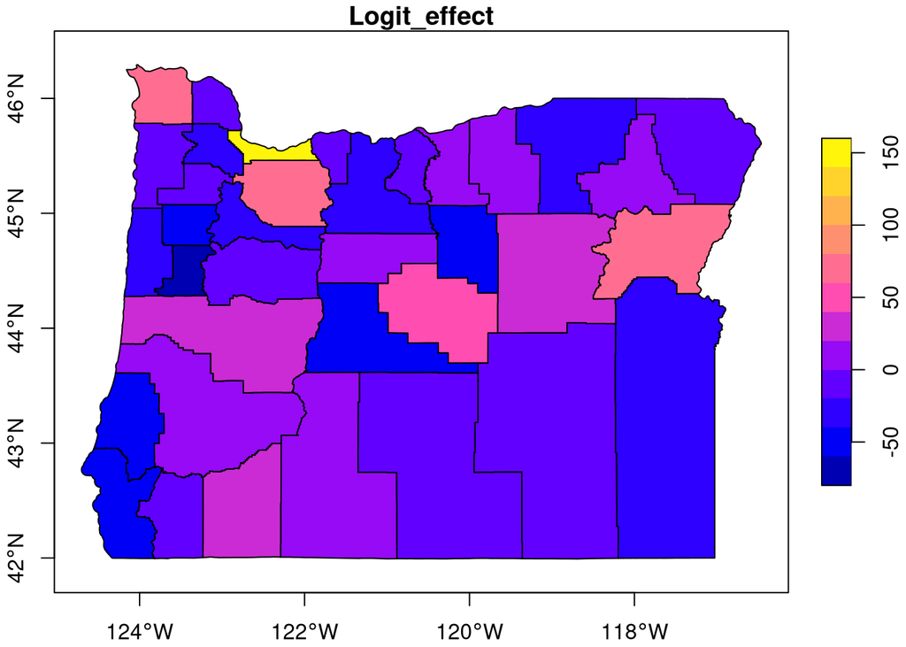

```r
counties$Logit_effect <- c(mean(output$Alpha[,1]),colMeans(output$A))
plot(counties["Logit_effect"], axes=TRUE)
```

We see that the Multnomah county is much more likely to be at risk of receiving landslides than the rest of the counties. When counties are at risk, the left side of the state is more likely to receive more landslides than the right side of the state.

Now, we can investigate the temporal random effects

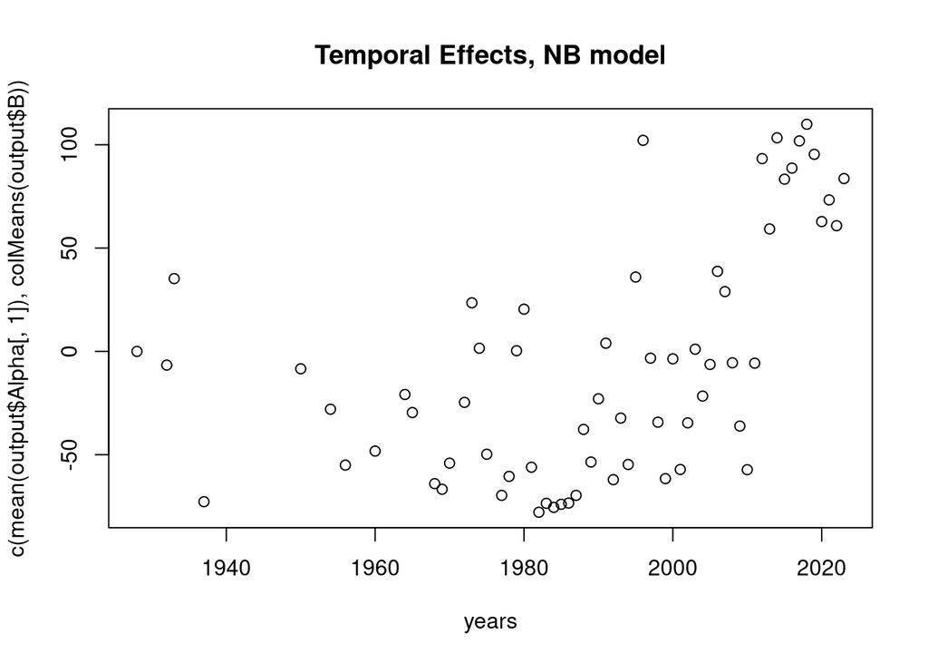

```r
years <- read.csv("./Years.csv")$X0
plot(years, c(mean(output$Alpha[,1]), colMeans(output$B)), main="Temporal Effects, NB model")
```

It seems that as time goes on, the frequency of observed landslides increases, perhaps this is due to better recording of landslides in the modern era? It appears that the temporal effects for the logistic (at-risk) model are unaffected however.

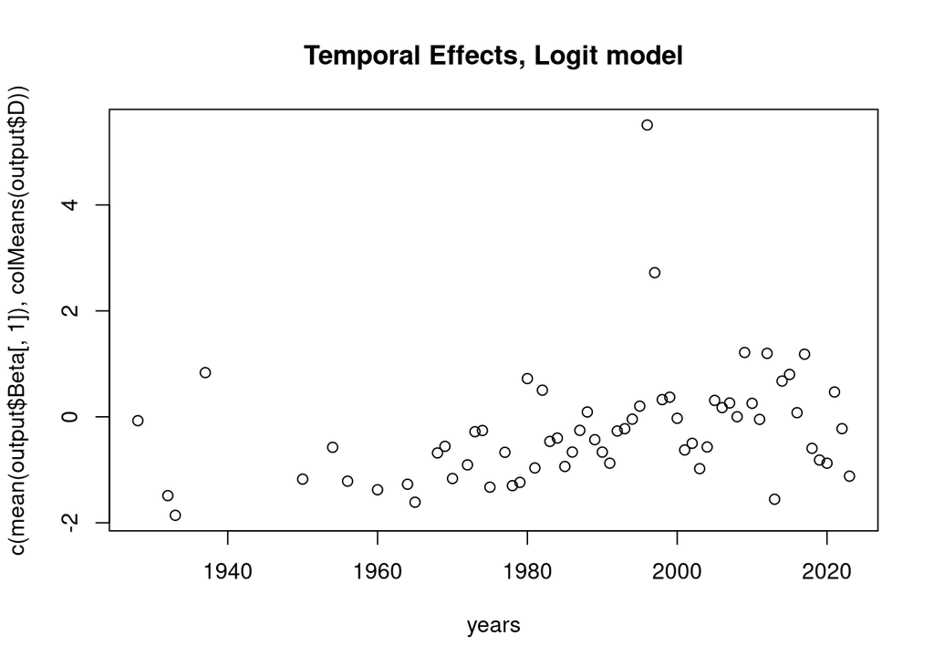

```r
plot(years, c(mean(output$Beta[,1]), colMeans(output$D)), main="Temporal Effects, Logit model")
```

Now, we can answer a potentially interesting question: If an event near the severity of the flood in 1996 was to occur again next year, which counties would likely have the most landslides, and what are likely bounds on the number of landslides that would occur? We can look at the at risk probability:

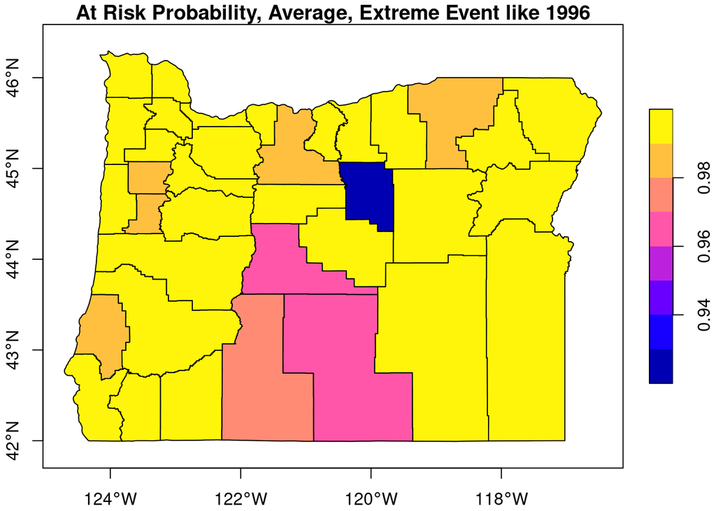

```r
logit <- \(x) log(x / (1 - x))
sigmoid <- \(x) 1 / (1 + exp(-x))

susceptAvg <- rowMeans(sigmoid(Vs %*% t(output$A) + quantile(output$B[,36], 0.90) + X %*% t(output$Alpha))) %*% Vs / 64
# Add an entry for the intercept county,
counties$lr_suscept_avg <- c(sigmoid(quantile(output$B[,36], 0.9) + mean(output$Alpha[,1])), susceptAvg)
plot(counties["lr_suscept_avg"], main="At Risk Probability, Average, Extreme Event like 1996", axes=TRUE)
```

And the NB results:

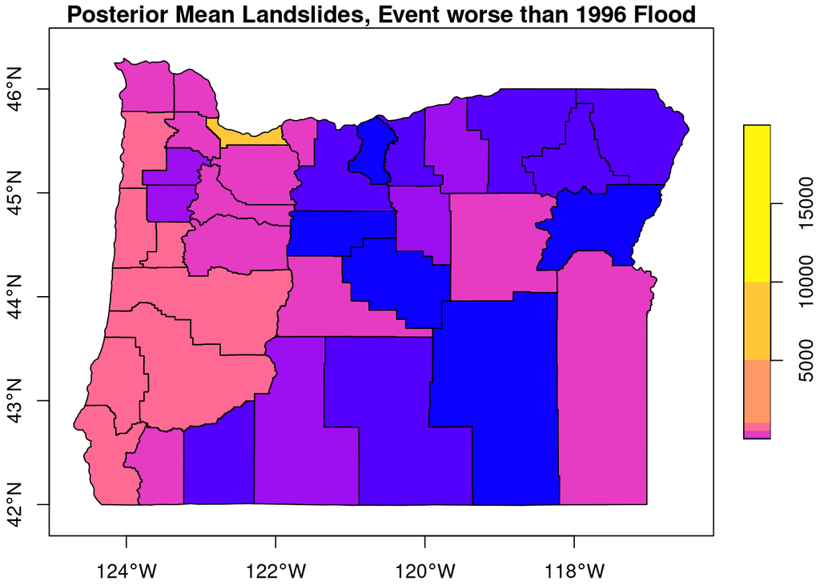

```r
# Simulate results of other years like 1996
int_rows <- apply(Vs == 0, 1, all)
p <- sigmoid(Vs %*% t(output$C) + quantile(output$D[,36], 0.90) + X %*% t(output$Beta))
rands <- matrix(0, nrow=nrow(p), ncol=ncol(p))
for (i in 1:nrow(p))
{
    for(j in 1:ncol(p))
    {
        rands[i,j] <- rnbinom(n=1, size=output$R[j], prob=(1 - p[i,j]))
    }
}
avgSlides <- rowMeans((t(Vs) %*% rands) / 64)
# Add an entry for the intercept
counties$nb_res_avg <- (c(mean(apply(rands[int_rows,], 2, sum) / 64) * sigmoid(quantile(output$B[,36], 0.9) + mean(output$Alpha[,1])), avgSlides * susceptAvg))
plot(counties["nb_res_avg"], main="Posterior Mean Landslides, Event worse than 1996 Flood", axes=TRUE, breaks=c(1, 5, 10, 50, 100, 500, 1000, 5000, 10000, 20000))
```

Since the model typically sees that the most landslides occur in Multnomah, it predicts that this county is at high risk if a severe landslide causing event, similar to the flood that caused many landslides in the counties below it was to occur there.

Trace plots for this run can be found in the trace folder if interested.